# [FastQC](https://www.bioinformatics.babraham.ac.uk/projects/fastqc/) report

# Run FastQC

```bash
cp /export/galaxy-central/database/files/000/dataset_1.dat read_1.fq
cp /export/galaxy-central/database/files/000/dataset_5.dat read_2.fq

fastqc \
  -q \
  /export/galaxy-central/database/job_working_directory/000/3/dataset_6_files/read_1.fq > /dev/null 2>&1

fastqc \
  -q \
  /export/galaxy-central/database/job_working_directory/000/3/dataset_6_files/read_2.fq > /dev/null 2>&1
```

# Fastqc Output Visualization

## Overview

| MODULE | Pre-trimming | Post-trimming |
| --- | --- | --- |
| Basic Statistics | PASS | PASS |
| Per base sequence quality | PASS | PASS |
| Per tile sequence quality | PASS | PASS |
| Per sequence quality scores | PASS | PASS |
| Per base sequence content | FAIL (X) | FAIL (X) |
| Per sequence GC content | FAIL (X) | FAIL (X) |
| Per base N content | PASS | PASS |
| Sequence Length Distribution | WARN (!) | WARN (!) |
| Sequence Duplication Levels | PASS | PASS |
| Overrepresented sequences | FAIL (X) | FAIL (X) |
| Adapter Content | PASS | PASS |
| Kmer Content | WARN (!) | WARN (!) |

### Per base sequence quality

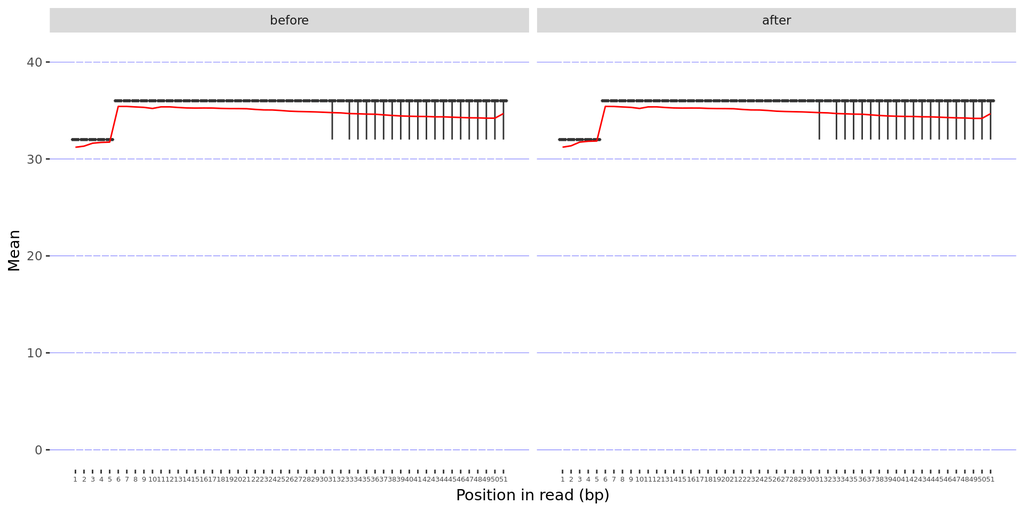

### Per tile sequence quality

[interactive chart not shown]

### Per sequence quality score

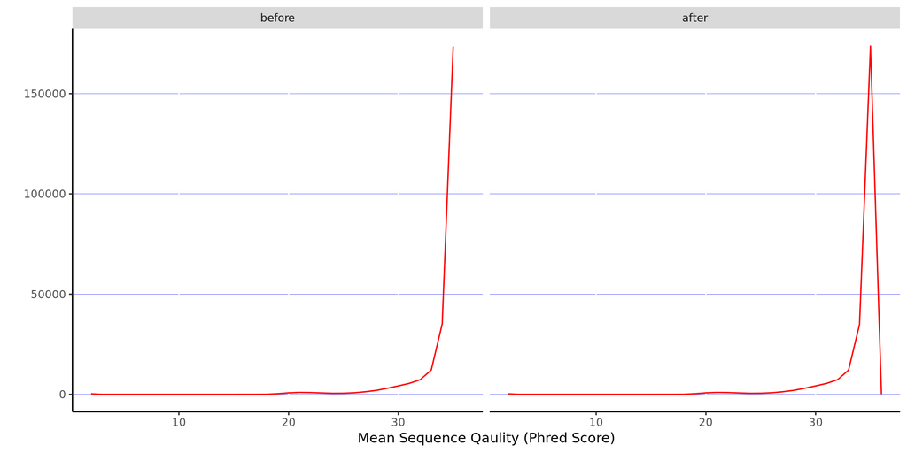

### Per base sequence content

[interactive chart not shown]

### Per sequence GC content

[interactive chart not shown]

### Per base N content

[interactive chart not shown]

### Sequence Length Distribution

[interactive chart not shown]

### Sequence Duplication Levels

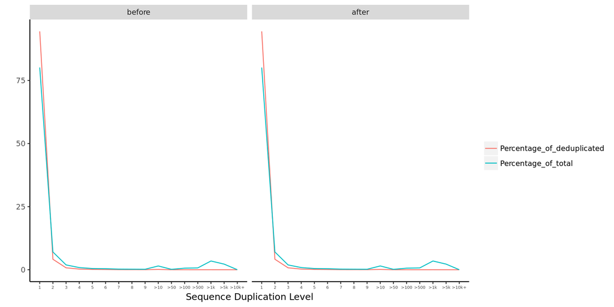

### Adapter Content

[interactive chart not shown]

### Kmer Content

#### Before

| X.Sequence | Count | PValue | Obs.Exp.Max | Max.Obs.Exp.Position |
| --- | --- | --- | --- | --- |
| CCGGTAT | 20 | 0.0007395 | 44.53062 | 1 |
| TGGGGGG | 360 | 0.0000000 | 42.67518 | 1 |
| CTCGAGT | 40 | 0.0000167 | 33.39797 | 1 |
| AGGGGGG | 45 | 0.0013010 | 24.73924 | 1 |
| ATTTCGG | 50 | 0.0024044 | 22.26086 | 10 |
| CCCCCCC | 2485 | 0.0000000 | 21.41412 | 1 |
| ATCTACA | 55 | 0.0041788 | 20.23714 | 18 |
| AGGCAGC | 55 | 0.0041788 | 20.23714 | 10 |
| TCCAGGA | 80 | 0.0018322 | 16.69564 | 7 |
| CCCCCCT | 1340 | 0.0000000 | 15.11745 | 3 |
| CTCCTTT | 175 | 0.0000009 | 13.99534 | 1 |
| CCCCCTT | 1530 | 0.0000000 | 13.38561 | 4 |
| TCAAGTT | 135 | 0.0002889 | 13.19162 | 8 |
| CCCCTTT | 1685 | 0.0000000 | 12.15430 | 5 |
| GGGGAAA | 270 | 0.0000001 | 11.54729 | 29 |
| CTCCATT | 135 | 0.0043173 | 11.54498 | 1 |
| CCCTTTT | 1795 | 0.0000000 | 11.40946 | 6 |
| CCTTTTT | 1890 | 0.0000000 | 10.83597 | 7 |
| GGGGGAA | 275 | 0.0000011 | 10.52542 | 28 |
| GGGGGGA | 300 | 0.0000003 | 10.39048 | 27 |

#### After

| X.Sequence | Count | PValue | Obs.Exp.Max | Max.Obs.Exp.Position |
| --- | --- | --- | --- | --- |
| CCGGTAT | 20 | 0.0007472 | 44.43715 | 1 |
| TGGGGGG | 360 | 0.0000000 | 42.58561 | 1 |
| CTCGAGT | 40 | 0.0000170 | 33.32786 | 1 |
| AGGGGGG | 45 | 0.0013170 | 24.68731 | 1 |
| ATTTCGG | 50 | 0.0024339 | 22.21413 | 10 |
| CCCCCCC | 2485 | 0.0000000 | 21.36917 | 1 |
| ATCTACA | 55 | 0.0042299 | 20.19466 | 18 |
| AGGCAGC | 55 | 0.0042299 | 20.19466 | 10 |
| TCCAGGA | 80 | 0.0018581 | 16.66060 | 7 |
| TCAACCA | 95 | 0.0003096 | 16.36830 | 7 |
| CCCCCCT | 1340 | 0.0000000 | 15.08571 | 3 |
| CTCCTTT | 175 | 0.0000009 | 13.96596 | 1 |
| CCCCCTT | 1530 | 0.0000000 | 13.35751 | 4 |
| CCCCTTT | 1685 | 0.0000000 | 12.12878 | 5 |
| GGGGAAA | 270 | 0.0000001 | 11.52305 | 29 |
| CTCCATT | 135 | 0.0043855 | 11.52074 | 1 |
| CCCTTTT | 1795 | 0.0000000 | 11.38551 | 6 |
| CCTTTTT | 1890 | 0.0000000 | 10.81323 | 7 |
| GGGGGAA | 275 | 0.0000012 | 10.50333 | 28 |
| GGGGGGA | 300 | 0.0000003 | 10.36867 | 27 |

## Outputs

- job-1-script.sh
- read_1_fastqc.html
- read_1_fastqc.zip
- read_1.fq
- read_2_fastqc.html
- read_2_fastqc.zip
- read_2.fq
- rmarkdown_report.Rmd
- read_1_fastqc
  - fastqc_data.txt
  - fastqc_report.html
  - fastqc.fo
  - summary.txt
  - Icons
    - error.png
    - fastqc_icon.png
    - tick.png
    - warning.png
  - Images
    - adapter_content.png
    - duplication_levels.png
    - kmer_profiles.png
    - per_base_n_content.png
    - per_base_quality.png
    - per_base_sequence_content.png
    - per_sequence_gc_content.png
    - per_sequence_quality.png
    - per_tile_quality.png
    - sequence_length_distribution.png
- read_2_fastqc
  - fastqc_data.txt
  - fastqc_report.html
  - fastqc.fo
  - summary.txt
  - Icons
    - error.png
    - fastqc_icon.png
    - tick.png
    - warning.png
  - Images
    - adapter_content.png
    - duplication_levels.png
    - kmer_profiles.png
    - per_base_n_content.png
    - per_base_quality.png
    - per_base_sequence_content.png
    - per_sequence_gc_content.png
    - per_sequence_quality.png
    - per_tile_quality.png
    - sequence_length_distribution.png
- rmarkdown_report_files
  - figure-html
    - per base sequence quality-1.png
    - Per sequence quality score-1.png
    - Sequence Duplication Levels-1.png